# Practical Machine Learning Course Project

Rashid Istami

1/4/2017

### Executive Summary

In this project, we will use data from accelerometers on the belt, forearm, arm, and dumbell of 6 participants. Participants were asked to perform barbell lifts correctly and incorrectly in 5 different ways. More information is available from the website [here.](http://groupware.les.inf.puc-rio.br/har) The goal of this project is to predict the manner in which they did the exercise, specifically, we are trying to predict the outcome of the variable classe. Training data set was downloaded from [here](https://d396qusza40orc.cloudfront.net/predmachlearn/pml-training.csv) and Test data set was downloaded from [here.](https://d396qusza40orc.cloudfront.net/predmachlearn/pml-testing.csv)

#### Load required libraries

```r
library(caret)
library(rattle)
```

```r
library(rpart)
library(rpart.plot)
library(randomForest)
```

### Exploratory Data Analysis

Firstly, we perform some expolarotary data analysis to understand the data sets and perform data clean up as needed.

```r
training <- read.csv("pml-training.csv", na.strings = c("NA", "#DIV/0!",""))
dim(training)
```

```
## [1] 19622   160
```

```r
testing <- read.csv("pml-testing.csv", na.strings = c("NA", "#DIV/0!",""))
dim(testing)
```

```
## [1]  20 160
```

As we can see, there are 160 variables on both data sets while training data set has 19622 observations, test data set has only 20 observations. Let us take a look at the variable names.

```r
colnames(training)
```

```
##   [1] "X"                        "user_name"
##   [3] "raw_timestamp_part_1"     "raw_timestamp_part_2"
##   [5] "cvtd_timestamp"           "new_window"
##   [7] "num_window"               "roll_belt"
##   [9] "pitch_belt"               "yaw_belt"
##  [11] "total_accel_belt"         "kurtosis_roll_belt"
##  [13] "kurtosis_picth_belt"      "kurtosis_yaw_belt"
##  [15] "skewness_roll_belt"       "skewness_roll_belt.1"
##  [17] "skewness_yaw_belt"        "max_roll_belt"
##  [19] "max_picth_belt"           "max_yaw_belt"
##  [21] "min_roll_belt"            "min_pitch_belt"
##  [23] "min_yaw_belt"             "amplitude_roll_belt"
##  [25] "amplitude_pitch_belt"     "amplitude_yaw_belt"
##  [27] "var_total_accel_belt"     "avg_roll_belt"
##  [29] "stddev_roll_belt"         "var_roll_belt"
```

[output cut: 65 more lines]

Based on variable names, we will not need columns 1-7 for our analysis, thus we wil remove those columns.

```r
training<-training[,-c(1:7)]
testing<-testing[,-c(1:7)]
```

Let us check percentage of NAs for each variable.

```r
nas<-colMeans(is.na(training))
print(nas)
```

```
##                roll_belt               pitch_belt                 yaw_belt
##                0.0000000                0.0000000                0.0000000
##         total_accel_belt       kurtosis_roll_belt      kurtosis_picth_belt
##                0.0000000                0.9798186                0.9809398
##        kurtosis_yaw_belt       skewness_roll_belt     skewness_roll_belt.1
##                1.0000000                0.9797676                0.9809398
##        skewness_yaw_belt            max_roll_belt           max_picth_belt
##                1.0000000                0.9793089                0.9793089
##             max_yaw_belt            min_roll_belt           min_pitch_belt
##                0.9798186                0.9793089                0.9793089
##             min_yaw_belt      amplitude_roll_belt     amplitude_pitch_belt
##                0.9798186                0.9793089                0.9793089
##       amplitude_yaw_belt     var_total_accel_belt            avg_roll_belt
##                0.9798186                0.9793089                0.9793089
##         stddev_roll_belt            var_roll_belt           avg_pitch_belt
##                0.9793089                0.9793089                0.9793089
##        stddev_pitch_belt           var_pitch_belt             avg_yaw_belt
##                0.9793089                0.9793089                0.9793089
##          stddev_yaw_belt             var_yaw_belt             gyros_belt_x
##                0.9793089                0.9793089                0.0000000
##             gyros_belt_y             gyros_belt_z             accel_belt_x
##                0.0000000                0.0000000                0.0000000
##             accel_belt_y             accel_belt_z            magnet_belt_x
##                0.0000000                0.0000000                0.0000000
##            magnet_belt_y            magnet_belt_z                 roll_arm
##                0.0000000                0.0000000                0.0000000
##                pitch_arm                  yaw_arm          total_accel_arm
##                0.0000000                0.0000000                0.0000000
##            var_accel_arm             avg_roll_arm          stddev_roll_arm
##                0.9793089                0.9793089                0.9793089
##             var_roll_arm            avg_pitch_arm         stddev_pitch_arm
##                0.9793089                0.9793089                0.9793089
##            var_pitch_arm              avg_yaw_arm           stddev_yaw_arm
##                0.9793089                0.9793089                0.9793089
##              var_yaw_arm              gyros_arm_x              gyros_arm_y
##                0.9793089                0.0000000                0.0000000
##              gyros_arm_z              accel_arm_x              accel_arm_y
##                0.0000000                0.0000000                0.0000000
##              accel_arm_z             magnet_arm_x             magnet_arm_y
##                0.0000000                0.0000000                0.0000000
```

[output cut: 47 more lines]

```
##                0.9793089                0.9793089                0.9835898
##      total_accel_forearm        var_accel_forearm         avg_roll_forearm
##                0.0000000                0.9793089                0.9793089
##      stddev_roll_forearm         var_roll_forearm        avg_pitch_forearm
##                0.9793089                0.9793089                0.9793089
##     stddev_pitch_forearm        var_pitch_forearm          avg_yaw_forearm
##                0.9793089                0.9793089                0.9793089
##       stddev_yaw_forearm          var_yaw_forearm          gyros_forearm_x
##                0.9793089                0.9793089                0.0000000
##          gyros_forearm_y          gyros_forearm_z          accel_forearm_x
##                0.0000000                0.0000000                0.0000000
##          accel_forearm_y          accel_forearm_z         magnet_forearm_x
##                0.0000000                0.0000000                0.0000000
##         magnet_forearm_y         magnet_forearm_z                   classe
##                0.0000000                0.0000000                0.0000000
```

As we can see that there are some variables that have almost 98% NAs. We will remove those columns.

```r
training<-training[ , colSums(is.na(training)) == 0]
testing<-testing[ , colSums(is.na(testing)) == 0]
```

Now we romove any columns that has near zero variance.

```r
nzv <- nearZeroVar(training, saveMetrics=TRUE)
training <- training[,nzv$nzv==FALSE]

nzv <- nearZeroVar(testing, saveMetrics=TRUE)
testing <- testing[,nzv$nzv==FALSE]
```

Now, let us check remaining variables in training and test data sets

```r
colnames(training)
```

```
##  [1] "roll_belt"            "pitch_belt"           "yaw_belt"
##  [4] "total_accel_belt"     "gyros_belt_x"         "gyros_belt_y"
##  [7] "gyros_belt_z"         "accel_belt_x"         "accel_belt_y"
## [10] "accel_belt_z"         "magnet_belt_x"        "magnet_belt_y"
## [13] "magnet_belt_z"        "roll_arm"             "pitch_arm"
## [16] "yaw_arm"              "total_accel_arm"      "gyros_arm_x"
## [19] "gyros_arm_y"          "gyros_arm_z"          "accel_arm_x"
## [22] "accel_arm_y"          "accel_arm_z"          "magnet_arm_x"
## [25] "magnet_arm_y"         "magnet_arm_z"         "roll_dumbbell"
## [28] "pitch_dumbbell"       "yaw_dumbbell"         "total_accel_dumbbell"
## [31] "gyros_dumbbell_x"     "gyros_dumbbell_y"     "gyros_dumbbell_z"
## [34] "accel_dumbbell_x"     "accel_dumbbell_y"     "accel_dumbbell_z"
## [37] "magnet_dumbbell_x"    "magnet_dumbbell_y"    "magnet_dumbbell_z"
## [40] "roll_forearm"         "pitch_forearm"        "yaw_forearm"
## [43] "total_accel_forearm"  "gyros_forearm_x"      "gyros_forearm_y"
## [46] "gyros_forearm_z"      "accel_forearm_x"      "accel_forearm_y"
## [49] "accel_forearm_z"      "magnet_forearm_x"     "magnet_forearm_y"
## [52] "magnet_forearm_z"     "classe"
```

```r
colnames(testing)
```

```
##  [1] "roll_belt"            "pitch_belt"           "yaw_belt"
##  [4] "total_accel_belt"     "gyros_belt_x"         "gyros_belt_y"
##  [7] "gyros_belt_z"         "accel_belt_x"         "accel_belt_y"
## [10] "accel_belt_z"         "magnet_belt_x"        "magnet_belt_y"
## [13] "magnet_belt_z"        "roll_arm"             "pitch_arm"
## [16] "yaw_arm"              "total_accel_arm"      "gyros_arm_x"
## [19] "gyros_arm_y"          "gyros_arm_z"          "accel_arm_x"
## [22] "accel_arm_y"          "accel_arm_z"          "magnet_arm_x"
## [25] "magnet_arm_y"         "magnet_arm_z"         "roll_dumbbell"
## [28] "pitch_dumbbell"       "yaw_dumbbell"         "total_accel_dumbbell"
## [31] "gyros_dumbbell_x"     "gyros_dumbbell_y"     "gyros_dumbbell_z"
## [34] "accel_dumbbell_x"     "accel_dumbbell_y"     "accel_dumbbell_z"
## [37] "magnet_dumbbell_x"    "magnet_dumbbell_y"    "magnet_dumbbell_z"
## [40] "roll_forearm"         "pitch_forearm"        "yaw_forearm"
## [43] "total_accel_forearm"  "gyros_forearm_x"      "gyros_forearm_y"
## [46] "gyros_forearm_z"      "accel_forearm_x"      "accel_forearm_y"
## [49] "accel_forearm_z"      "magnet_forearm_x"     "magnet_forearm_y"
## [52] "magnet_forearm_z"     "problem_id"
```

It is good that except the last variable in both data sets, other variables are same. Remove last column from testing.

```r
testing<-testing[,-53]
```

### Prediction Models

We will build multiple models and pick one based on accuracy.

First, split training data into train and validation sets on 80/20 split.

```r
set.seed(123456)
tr <- createDataPartition(training$classe, p = 0.8, list = FALSE)
train <- training[tr, ]
validation<-training[-tr, ]
```

#### Decision Tree Model

```r
set.seed(98765)
control <- trainControl(method = "cv", number = 5)
fit1 <- train(classe ~ ., data = train, method = "rpart",trControl = control)
print(fit1)
```

```
## CART
##
## 15699 samples
##    52 predictor
##     5 classes: 'A', 'B', 'C', 'D', 'E'
##
## No pre-processing
## Resampling: Cross-Validated (5 fold)
## Summary of sample sizes: 12560, 12560, 12560, 12558, 12558
## Resampling results across tuning parameters:
##
##   cp          Accuracy   Kappa
##   0.03346684  0.5022614  0.35029603
##   0.05954606  0.4659470  0.29253806
##   0.11384068  0.3154320  0.04736791
##
## Accuracy was used to select the optimal model using  the largest value.
## The final value used for the model was cp = 0.03346684.
```

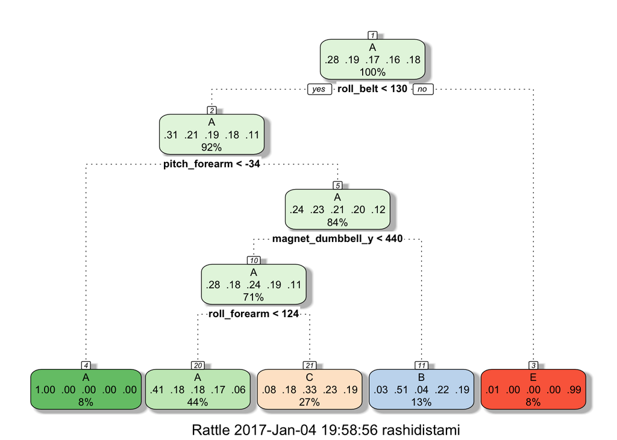

```r
fancyRpartPlot(fit1$finalModel)
```

```r
# predict outcome using validation data set
predict1 <- predict(fit1, validation)
# check prediction results
confm1 <- confusionMatrix(validation$classe, predict1)
print(confm1)
```

```
## Confusion Matrix and Statistics
##
##           Reference
## Prediction    A    B    C    D    E
##          A 1025   13   74    0    4
##          B  317  256  186    0    0
##          C  315   21  348    0    0
##          D  289  117  237    0    0
##          E  109  102  168    0  342
##
## Overall Statistics
##
##                Accuracy : 0.5024
##                  95% CI : (0.4867, 0.5182)
##     No Information Rate : 0.5238
##     P-Value [Acc > NIR] : 0.9965
##
##                   Kappa : 0.3493
##  Mcnemar's Test P-Value : NA
##
## Statistics by Class:
##
##                      Class: A Class: B Class: C Class: D Class: E
## Sensitivity            0.4988  0.50295  0.34353       NA  0.98844
## Specificity            0.9513  0.85267  0.88454   0.8361  0.89405
## Pos Pred Value         0.9185  0.33729  0.50877       NA  0.47434
## Neg Pred Value         0.6331  0.92004  0.79469       NA  0.99875
## Prevalence             0.5238  0.12975  0.25822   0.0000  0.08820
## Detection Rate         0.2613  0.06526  0.08871   0.0000  0.08718
## Detection Prevalence   0.2845  0.19347  0.17436   0.1639  0.18379
## Balanced Accuracy      0.7250  0.67781  0.61404       NA  0.94124
```

```r
# check accuracy
accuracy1 <- confm1$overall[1]
print(accuracy1)
```

```
##  Accuracy
## 0.5024216
```

Since, the model accuracy is 50%, out of sample error is 50%, meaning the decision tree model is not a good model to predict outcome.

#### Random Forest Model

Since decision tree model did not predict outcome well, let us try random forest model.

```r
fit2 <- train(classe ~ ., data = train, method = "rf",trControl = control)
print(fit2)
```

```
## Random Forest
##
## 15699 samples
##    52 predictor
##     5 classes: 'A', 'B', 'C', 'D', 'E'
##
## No pre-processing
## Resampling: Cross-Validated (5 fold)
## Summary of sample sizes: 12557, 12559, 12560, 12560, 12560
## Resampling results across tuning parameters:
##
##   mtry  Accuracy   Kappa
##    2    0.9924838  0.9904913
##   27    0.9915279  0.9892830
##   52    0.9834386  0.9790476
##
## Accuracy was used to select the optimal model using  the largest value.
## The final value used for the model was mtry = 2.
```

```r
# predict outcomes using validation set
predict2 <- predict(fit2, validation)
# Show prediction result
confm2 <- confusionMatrix(validation$classe, predict2)
print(confm2)
```

```
## Confusion Matrix and Statistics
##
##           Reference
## Prediction    A    B    C    D    E
##          A 1116    0    0    0    0
##          B    5  750    4    0    0
##          C    0    6  677    1    0
##          D    0    0    7  636    0
##          E    0    0    0    3  718
##
## Overall Statistics
##
##                Accuracy : 0.9934
##                  95% CI : (0.9903, 0.9957)
##     No Information Rate : 0.2858
##     P-Value [Acc > NIR] : < 2.2e-16
##
##                   Kappa : 0.9916
##  Mcnemar's Test P-Value : NA
##
## Statistics by Class:
##
##                      Class: A Class: B Class: C Class: D Class: E
## Sensitivity            0.9955   0.9921   0.9840   0.9938   1.0000
## Specificity            1.0000   0.9972   0.9978   0.9979   0.9991
## Pos Pred Value         1.0000   0.9881   0.9898   0.9891   0.9958
## Neg Pred Value         0.9982   0.9981   0.9966   0.9988   1.0000
## Prevalence             0.2858   0.1927   0.1754   0.1631   0.1830
## Detection Rate         0.2845   0.1912   0.1726   0.1621   0.1830
## Detection Prevalence   0.2845   0.1935   0.1744   0.1639   0.1838
## Balanced Accuracy      0.9978   0.9946   0.9909   0.9958   0.9995
```

```r
accuracy2 <- confm2$overall[1]
print(accuracy2)
```

```
##  Accuracy
## 0.9933724
```

The accuracy rate is 99.33%, therefore out-of-sample error is 0.67%, meaning randon forest model predicts outcome very well thus we will use random forest model to predict the outcome classe.

### Prediction on Testing Set

Now, we use the random forest model to predict classe variable on test data set.

```r
predict(fit2, testing)
```

```
##  [1] B A B A A E D B A A B C B A E E A B B B
## Levels: A B C D E
```

### Conclusion

We tried 2 different models and picked Random Forest model since it had very small out of sample error rate and predicted classe variable for testing data set.